# LIMMS_vignette

Jacob A. Mayfield

## 0.1 Introduction

The R package `limms`provides functions for both unsupervised and supervised analyses of mass spectrometry data. More specifically, it provides functions for exploratory data analysis, quality control, preprocessing, and normalization of mass spectrometry data. It also facilitates contrast-based analyses to identify compounds/molecules (e.g., adducts, metabolites) that are differentially abundant under different conditions (e.g., treatment/control, cell type). Study designs with multiple conditions benefit from the ability to specify the contrasts of interest, rather than rely on pairwise or one-vs-all comparisons. `limms` adapts the excellent `limma` package for transcriptomics to mass spectrometry. In addition to providing a portal to `limma` that maintains mass spectrometry peak information, `limms` provides the functions necessary to coerce mass spectrometry data into a format readable by `limma`. Downstream of differential abundance analysis, `limms` provides a function to match masses to a user-provided list of knowns.

`limms` accepts as input a table of *m/z* values that can come from any mass spectrometry platform or peak finding algorithm, as long as the rows correspond to mass peaks and columns to samples. It outputs a `limma` object, or can append a `limma` topTable to the input peak table. This output includes the adjusted p-value and fold-change needed to flag the compounds that differ significantly under a contrast of interest. This shorter list of changed *m/z*’s is easily amenable to data visualization and analysis, for example using heatmaps. A plot of 10,000 metabolites is hard to read, but a heatmap of 50 metabolites that differ significantly between classes is useful. This vignette includes examples of suggested data visualizations facilitated by `limms`.

This vignette demonstrates the `limms` package in R using the example CBS dataset provided with the package, which consists of metabolite abundances in *Saccharomyces cerevisiae* after complementation with human cystathionine beta-synthase (CBS) allele. All of the functions in `limms` are used in the vignette, plus several data visualizations that take advantage of the `limms` output. The vignette also corresponds to the help files for the `limms` package, but provides additional explanations. In contrast, the help files for individual `limms` functions may provide additional analyses not in the vignette, especially for quality control.

- The CBS data are in the dataset `CBS.xcms_diffreport`.
- A metabolite database file from the Human Metabolome Database corresponding to compounds included as internal controls in the mass spectrometry experiments is in the dataset `hmdb_Shortlist`.
- A topTable object of metabolites is produced by the code in this vignette, but is also included in the `limms` package as the dataset `ttF.CBS` for convenience.

## 0.2 Starting limms

An example pipeline from a table of *m/z* intensities to a significance table with putative identifiers is provided here. Start by loading `limms`.

The example data used the excellent `xcms` package for peak picking, grouping, and retention time alignment, with output as a `diffreport` object of aligned peaks in rows and sample intensities in columns. The `diffreport` also contains mass and retention time columns that can be passed through the `limms` functions, although only the intensities are needed. `xcms` or a `diffreport` are recommended but not required; however, the mass spectrometry data must be read in as a data frame with the peak intensities listed as columns.

Data input can be in any format, but `limmms` will internally convert to a data.table object to use functions from the `data.table` package. Some `limms` functions allow arguments that specify which columns contain names, intensities, or information. Peak names, i.e., the `xcms` mz@rt labels, can be specified and used, or if the rows are unspecified, `limms` will number the rows for consistent tracking. For the CBS dataset, columns 24 to 55 contain the peak data. There are additional columns of data from controls with isotopically labeled standards not used here.

## 0.3 Data Quality Control

The `limms` function `scatterQC` generates two data visualizations that can help to assess overall data quality, how sample classes are similar or different, and whether any samples are drastically different. The function displays the total number of non-zero ions in a dot plot and the intensity measurements in a boxplot. The samples can be grouped according to user-defined groupings, such that different experimental covariates, mass spec run order, or arbitrary groupings can be examined. The 5%, 25%, 50%, 75%, and 95%s quantiles across all samples are plotted as grey reference lines, and outliers can be displayed if desired.

These plots allow for exploratory data analysis that may suggest strategies for improving the downstream results. Differential abundance analysis relies on differences between sample classes, which may or may not be visible in `scatterQC` plots. However, these plots are intended to flag outlier samples, check for changes in quality over the course of a mass spectrometry run, or to identify sample classes that are different enough that peak picking and alignment may have suffered. In some cases, users may want to repeat the pick peaking step without problematic samples rather than simply excluding them from `limms` analysis.

To group the data, make a covariates object for the `CBS.xcms_diffreport` data set.

```r
# Extract the data columns from CBS.xcms_diffreport,
# an xcms diffreport object included as limms package data,

desMetB6 <- cbind(names(CBS.xcms_diffreport[,24:55]), c(rep("CBS",4), rep("CBS",4), rep("CBS",4),
rep("CBS",4), rep("CBS",4), rep("CBS",4), rep("G307S",4), rep("G307S",4)),
c(rep("Yes",4), rep("Yes",4), rep("Yes",4), rep("Yes",4), rep("No",4), rep("No",4),
rep("Yes",4), rep("Yes",4)),  c(rep("High",4), rep("High",4), rep("Low",4),
rep("Low",4), rep("High",4), rep("Low",4), rep("High",4), rep("Low",4)), c(rep(2,4),
rep(1,4), rep(2,4), rep(1,4), rep(1,4), rep(1,4), rep(2,4), rep(2,4)))
desMetB6 <- data.frame(desMetB6)
names(desMetB6) <- c("Run", "Strain", "Met", "B6", "Rep")

knitr::kable(desMetB6[1:5,], caption="Subset of the CBS covariates table")
```

Subset of the CBS covariates table

| Run | Strain | Met | B6 | Rep |
| --- | --- | --- | --- | --- |
| ORB17928 | CBS | Yes | High | 2 |
| ORB17935 | CBS | Yes | High | 2 |
| ORB17942 | CBS | Yes | High | 2 |
| ORB17949 | CBS | Yes | High | 2 |
| ORB17900 | CBS | Yes | High | 1 |

Plot the data, first by run order, then by methionine supplementation.

```
#> [1] "Warning: scatterQC performs a log transformation: input data should not be log transformed."
```

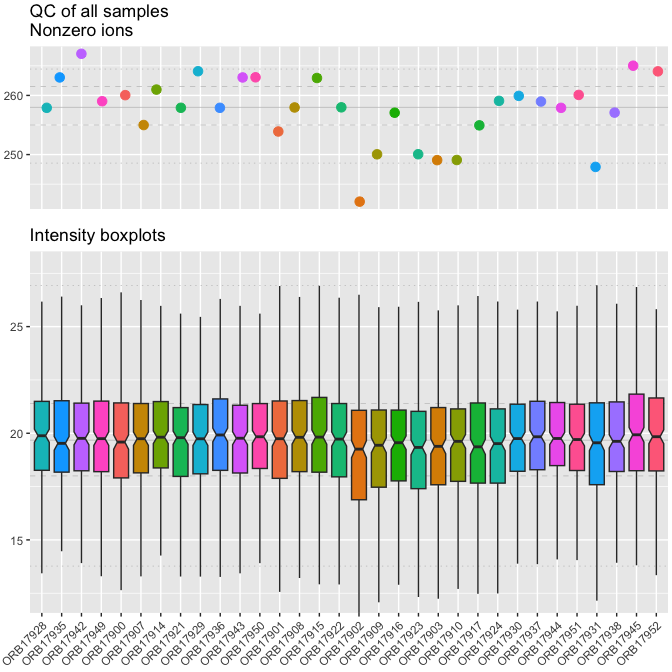

```r
# QC plot of all samples
# this can be useful for checking run order, etc
scatterQC(CBS.xcms_diffreport[, c(24:55)], seed=75, main="QC of all samples")
```

```
#> [1] "Warning: scatterQC performs a log transformation: input data should not be log transformed."
```

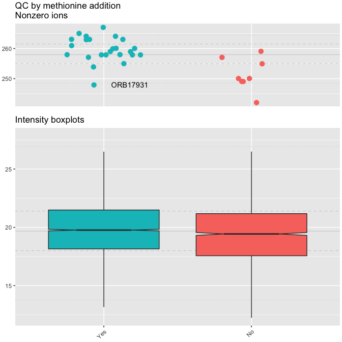

```r
# QC plot by group
# Treatments are expected to differ... but it's still useful to know which ones!
# flag outlier samples
scatterQC(CBS.xcms_diffreport[, c(24:55)], seed=75, groupNames=desMetB6$Met,
  main="QC by methionine addition", outlayer=TRUE)
```

## 0.4 Preprocessing and Normalization

Before statistical analysis such as clustering or inference of differential abundance, the intensity data benefit from:

- having zeros removed
- being log transformed
- being normalized

The `limms` function `imputeZerosUnifMin` imputes zeros, replacing them with random values between 1 and the actual sample minima. This was empirically determined to give reasonable results, and works under the assumption that the measured minima reflect the threshold of detection of the instrument. Users of `xcms` will be familiar with the `fillPeaks` family of functions that also aim to replace zeros, using a different method. `imputeZerosUnifMin` works well with `fillPeaks`, and removes any remaining zeros. `imputeZerosUnifMin` also performs log2 transformation by default, although transformation can be turned off using the `output="imputed"` argument.

Impute the zeros and log2 transform columns 24 to 55. To store the imputed values, call to a new object.

```r
all.i_l <- imputeZerosUnifMin(CBS.xcms_diffreport, intensities=24:55, seed=478)
```

**An important note:** because **random values below the minima are used for imputation**, the resulting object will be different each time `imputeZerosUnifMin` is called. Differences between calls are minor and affect compounds at or below the threshold for reliable measurement. Nonetheless, it can be convenient to have the same imputed values each time the analysis is run. This can be accomplished by specifying the seed to feed `imputeZerosUnifMin` inside the function using the `seed` argument, or like this:

```r
set.seed(2846)
```

where 2846 is a user chosen number, which should be reset to a different number for other, independent analyses.

Knowing the imputed compounds is important. To generate a new table with information about impounded measurements, the impounded measurements can be flagged and counted.

```r
metimp <- t(sapply(1:dim(CBS.xcms_diffreport)[1], function(i) CBS.xcms_diffreport[i, 24:55]==0))
```

```r
numimp <- sapply(1:dim(CBS.xcms_diffreport)[1], function(i) length(which(metimp[i,]=="TRUE")))
```

```r
# Quick QC according to the number of impounded measurements
# which peaks have no samples with impounded zeros?
summary(numimp == 0)
```

```
#>    Mode   FALSE    TRUE
#> logical     104     170
```

```r
# which peaks have > 5 impounded?
summary(numimp > 5)
```

```
#>    Mode   FALSE    TRUE
#> logical     241      33
```

For quick QC according to the number of impounded measurements, generate a table with information about impounded measurements including how many and which samples were impounded for each metabolite

```r
lcids <- sapply(1:dim(CBS.xcms_diffreport)[1], function(i)
  paste(as.character(
    colnames(CBS.xcms_diffreport[, 24:55])[which(CBS.xcms_diffreport[i, 24:55]==0)]),
    collapse="; "))

xi <- data.table(cbind(numimp,lcids))
head(xi)
```

```
#>    numimp
#>    <char>
#> 1:      9
#> 2:      5
#> 3:      2
#> 4:      0
#> 5:      0
#> 6:      0
#>                                                                                       lcids
#>                                                                                      <char>
#> 1: ORB17900; ORB17902; ORB17909; ORB17916; ORB17923; ORB17903; ORB17910; ORB17917; ORB17924
#> 2:                                         ORB17929; ORB17902; ORB17909; ORB17903; ORB17910
#> 3:                                                                       ORB17907; ORB17908
#> 4:
#> 5:
#> 6:
```

The `limms` function `runNorm` normalizes the data across sample classes. Three methods for normalization are provided by setting the argument `method` to

- “FullQuantileNorm” for normalization by full quantiles,
- “globalScalingNorm” for scaling by the 75% quantile,
- “pc1Norm” for normalization by the first principal component.

A fourth method, “custom” allows a custom normalization method to be used by setting FUN=your_custom_method.

“FullQuantileNorm” produced the best results for test datasets and is the default method.

Is normalization necessary? There may be experiments/cases where it is not advised; however, sample-to-sample technical variation, typical variation between biological replicates, and mass spectrometry issues like chromatographic drift and loss of sensitivity over a multi-sample run can confound differential abundance analyses and inflate false positive and false negative rates. Normalization helps remove unwanted technical effects, so that differences in intensities reflect biological effects of interest. Batch normalization is not part of `limms`, but can be implemented via `limma` or through `ComBat` in the `sva` package.

```r
all.fq <- runNorm(all.i_l, intensities=70:101)

# NOTE: you can also call intensities by pattern match
all.fq <- runNorm(all.i_l, intensities=grep("log2", names(all.i_l)))

# or by name
all.fq <- runNorm(all.i_l, intensities=names(all.i_l[, .SD, .SDcols=patterns("log2")]))

# which has advantages in making code portable if something changes
# or you want to use as a template
```

Normalize by other methods as a comparison

```r
# Normalization by global scaling
all.gs <- runNorm(all.i_l, intensities=70:101, method="globalScalingNorm")

# Normalization by principal components
all.pc1 <- runNorm(all.i_l, intensities=70:101, method="pc1Norm")

# Normalization using a custom function, scaling to the median
# For demonstration of a custom function only: this method is not recommended.
medPeak <- function(x)
      {
        # x[, .(scale(x, center=TRUE, scale=FALSE))]
        x[, .(scale(x, center = (unlist(x[, .(lapply(.SD, function(i)
          stats::median(unlist(i, use.names = FALSE)))), .SDcols = names(x)]) -
            unlist(x[, .(stats::median(unlist(.SD, use.names = FALSE))),
            .SDcols = names(x)], use.names = FALSE)), scale = FALSE)
          )]
      }

all.med <- runNorm(all.i_l, intensities=70:101, method="custom", FUN=medPeak)
```

What did the normalization do?

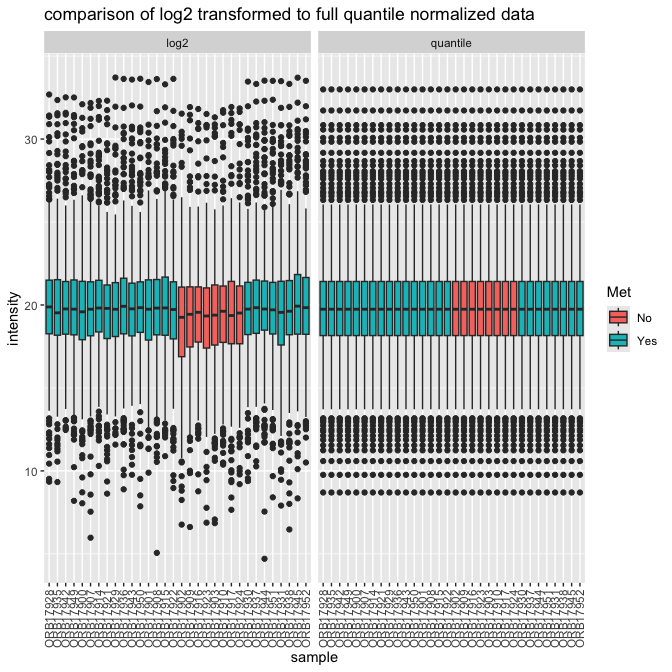

```r
# add a color key
# methionine starvation induced the largest changes
# make the methionine starvation condition pale green
colCBS <- data.table(desMetB6)

# Boxplots of log intensities

all.fq.melt <- data.table(reshape2::melt(all.fq, id.vars=1:69, value.name="intensity",
 variable.name="sample"))
all.fq.melt[, Run := gsub("\\..*$", "", sample)]
all.fq.melt[, transform := gsub("^.*\\.", "", sample)]
all.fq.melt[, transform := gsub("norm", "quantile", transform)]

all.fq.melt <- merge(all.fq.melt, colCBS, by="Run", sort=FALSE)

ggplot(all.fq.melt, aes(x=fct_inorder(Run), y=intensity)) +
  geom_boxplot(aes(fill=Met)) +
  facet_wrap(~transform, scales="free_x") +
  theme(axis.text.x=element_text(angle=90, vjust=0.5)) +
  xlab("sample") +
  ggtitle("comparison of log2 transformed to full quantile normalized data")
```

Comparison of normalization methods.

```r
norm.list <- list(quantile=all.fq[, 102:133], global_scaling=all.gs[, 102:133],
 pc1=all.pc1[, 102:133], median=all.med[, 102:133])
all.norm.melt <- data.table(reshape2::melt(norm.list, value.name="intensity",
 variable.name="sample"))
```

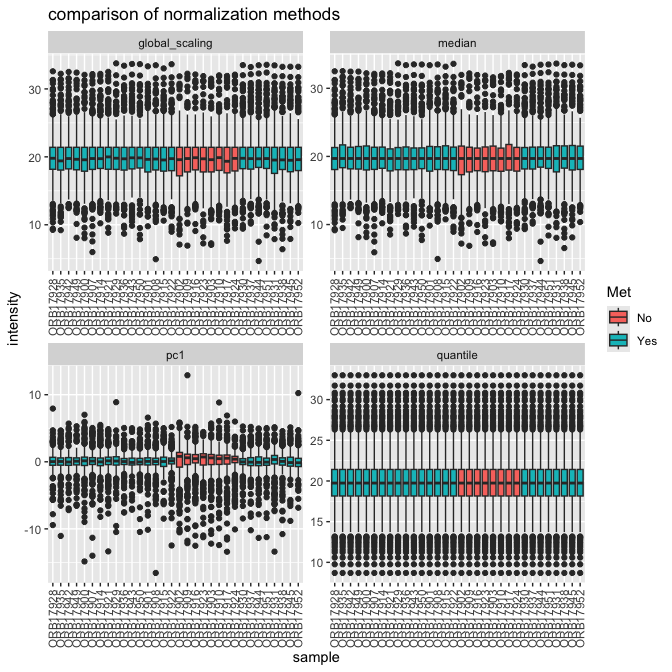

```r
all.norm.melt[, Run := gsub("\\..*$", "", sample)]
all.norm.melt[, transform := gsub("^.*\\.", "", sample)]
all.norm.melt[, transform := gsub("norm", "quantile", transform)]
all.norm.melt <- merge(all.norm.melt, colCBS, by="Run", sort=FALSE)

ggplot(all.norm.melt, aes(x=fct_inorder(Run), y=intensity)) +
  geom_boxplot(aes(fill=Met)) +
  facet_wrap(~L1, scales="free") +
  theme(axis.text.x=element_text(angle=90, vjust=0.5)) +
  xlab("sample") +
  ggtitle("comparison of normalization methods")
```

Normalization by the first principal component alters the scale of the abundance measures, making comparisons to other methods difficult. In context of normalization, it is often more informative to compare relative log expression (RLE) measures, where the RLE of a given compound in a given sample is the log ratio of the intensity to the median intensity of the compound across samples. `relLog` is a `limms` internal function for computing RLEs.

```r
norm.list <- list(
  quantile=relLog(all.fq, intensities=102:133)[, .SD, .SDcols=patterns("rle")],
  global_scaling=relLog(all.gs, intensities=102:133)[, .SD, .SDcols=patterns("rle")],
  pc1=relLog(all.pc1, intensities=102:133)[, .SD, .SDcols=patterns("rle")],
  median=relLog(all.med, intensities=102:133)[, .SD, .SDcols=patterns("rle")])
all.norm.melt <- data.table(reshape2::melt(norm.list, value.name="intensity",
 variable.name="sample"))
```

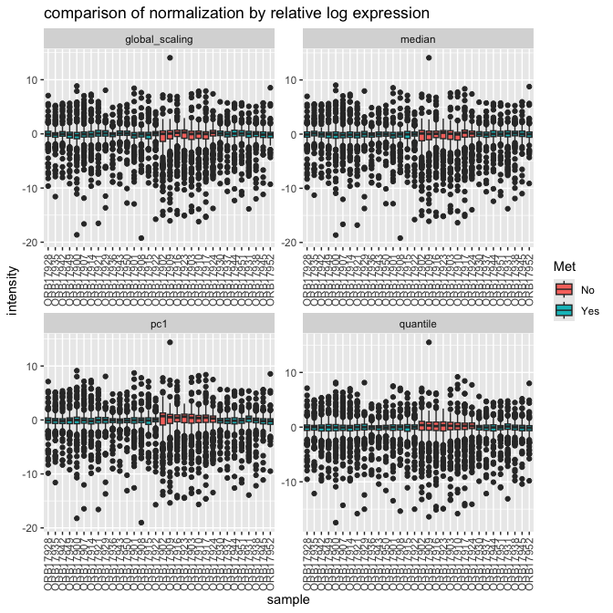

```r
all.norm.melt[, Run := gsub("\\..*$", "", sample)]
all.norm.melt <- merge(all.norm.melt, colCBS, by="Run", sort=FALSE)

ggplot(all.norm.melt, aes(x=fct_inorder(Run), y=intensity)) +
  geom_boxplot(aes(fill=Met)) +
  facet_wrap(~L1, scales="free") +
  theme(axis.text.x=element_text(angle=90, vjust=0.5)) +
  xlab("sample") +
  ggtitle("comparison of normalization by relative log expression")
```

## 0.5 Building Contrasts

Since `limms` relies on `limma` for differential abundance analysis, it adopts the `limma` input structure. As a contrast-based method, `limms` requires input of R objects to specify the experimental design and contrasts to make, in addition to the mass spectrometry data.

These objects can be built in different ways. The `limma` manual and vignette include a detailed, formal discussion of these objects that is required reading to understand how the output is generated and what interpretations can be made. The `stats` function `model.matrix` and `limma` function `makeContrasts` are helpful to build the correct objects. Be aware that the default behaviors for `model.matrix` and `makeContrasts` may add intercept terms, not encode the desired contrast, or include contrasts that are neither of interest nor necessary.

Here, a design matrix and a contrast matrix for the CBS dataset is used as an example.

First, we detail the experimental design. For the CBS dataset, the variables are:

- Run = the mass spectrometry sample run number,
- Strain = whether the cells had the major CBS allele or the nonfunctional G307S allele,
- Met = whether methionine was added to the medium to stimulate CBS flux,
- B6 = whether vitamin B6 was added at optimal or limiting concentration,
- Rep = whether the cells belonged to replicate batch 1 or 2.

These are contained in `desMetB6`, the covariate table used for `scatterQC` above.

Now build the design matrix.

Start by choosing the covariates on which to base the contrasts:

```r
f <- paste(desMetB6$Strain, desMetB6$Met, desMetB6$B6, desMetB6$Rep, sep="")
f <- factor(f)
```

The `stats` function `model.matrix` is useful for converting the factor levels data into a design matrix.

```r
desCu <- model.matrix(~0+f)
colnames(desCu) <- levels(f)

knitr::kable(desCu[1:5, ], caption="Subset of the CBS design matrix")   # Check the design matrix.
```

Subset of the CBS design matrix

| CBSNoHigh1 | CBSNoLow1 | CBSYesHigh1 | CBSYesHigh2 | CBSYesLow1 | CBSYesLow2 | G307SYesHigh2 | G307SYesLow2 |
| --- | --- | --- | --- | --- | --- | --- | --- |
| 0 | 0 | 0 | 1 | 0 | 0 | 0 | 0 |
| 0 | 0 | 0 | 1 | 0 | 0 | 0 | 0 |
| 0 | 0 | 0 | 1 | 0 | 0 | 0 | 0 |
| 0 | 0 | 0 | 1 | 0 | 0 | 0 | 0 |
| 0 | 0 | 1 | 0 | 0 | 0 | 0 | 0 |

Now build the contrast matrix.

While many contrasts are possible for the CBS data, only four are interesting. - `MA_B6` compares cells with the major allele at high versus low concentrations of the CBS cofactor vitamin B6; - `Strain_w_B6` compares the major allele to G307S at high vitamin B6; - `Strain_by_B6` is a compound contrast comparing metabolites that vary with both B6 concentration and allele; and - `CBS_Met` compares the major allele under methionine replete versus starvation medium to contrast growth restriction due to low pathway flux to a CBS block.

```r
contMatrix <- makeContrasts(MA_B6="(CBSYesLow1+CBSYesLow2)-(CBSYesHigh1+CBSYesHigh2)",
    Strain_w_B6="G307SYesHigh2-CBSYesHigh2",
    Strain_by_B6="(G307SYesLow2-G307SYesHigh2)-(CBSYesLow2-CBSYesHigh2)",
    CBS_Met="CBSNoHigh1-CBSYesHigh1", levels=desCu)

knitr::kable(contMatrix, caption="CBS contrast matrix") # Check the contrast matrix.
```

CBS contrast matrix

|  | MA_B6 | Strain_w_B6 | Strain_by_B6 | CBS_Met |
| --- | --- | --- | --- | --- |
| CBSNoHigh1 | 0 | 0 | 0 | 1 |
| CBSNoLow1 | 0 | 0 | 0 | 0 |
| CBSYesHigh1 | -1 | 0 | 0 | -1 |
| CBSYesHigh2 | -1 | -1 | 1 | 0 |
| CBSYesLow1 | 1 | 0 | 0 | 0 |
| CBSYesLow2 | 1 | 0 | -1 | 0 |
| G307SYesHigh2 | 0 | 1 | -1 | 0 |
| G307SYesLow2 | 0 | 0 | 1 | 0 |

All objects are now ready for testing. The design matrix `desCu` and contrast matrix `contMatrix` are used to set the `des` and `cont` arguments, respectively, in the function `limmaTest`.

## 0.6 Differential Abundance Analyses

Once the design and contrast matrices are built and the data are transformed into a `limma`-useable format, you could begin the analysis procedure outlined in the `limma` vignette. Alternatively, as a streamlined procedure,`limms` provides the function `limmaTest`.

By combining the `limma` functions `lmFit`, `contrasts.fit` and `eBayes`, `limmaTest` focuses on the functions most appropriate to mass spectrometry data. Using `limmaTest` also allows peak information columns like mass and retention time to be passed to the output.

Different types of study design can be handled through `limmaTest` by specifying a contrast matrix and/or block structure. A contrast matrix is not required; however, all contrasts from the design matrix are tested if a contrast matrix is not provided, which is desirable only in some cases. Likewise, `limmaTest` allows specification of blocks to call the `duplicateCorrelation` function for cases where this is needed. A tabular summary shows how `limma` functions can be accessed using `limmaTest` arguments.

**Summary of contrast-based options in `limmaTest`:**

| limmaTest arguments | limma functions used | usage case(s) |
| --- | --- | --- |
| cont=NULL block=NULL | `lmFit` `eBayes` | simple contrast; paired samples; all contrasts |
| cont specified block=NULL | `lmFit` `contrasts.fit` `eBayes` | select contrasts; compound contrasts |
| cont=NULL block specified | `lmFit` `duplicateCorrelation` `eBayes` | duplicated samples; blocks |
| cont specified block specified | `lmFit` `duplicateCorrelation` `contrasts.fit` `eBayes` | select paired; select within block |

Please refer to the `limma` help page for `lmFit` and/or the `limma` manual if this is unclear or for additional examples of design and contrast objects for different study designs.

The `limmaTest` output can also be directed to a `topTable` object that is appended to the input matrix. This is useful to get the peaklist data (mass, retention time) and statistical inference data (Benjamini-Hochberg adjusted p-value, log-fold-change) in one place, and is the default output. The `limma` `eBayes` output is available by setting `limma_out=TRUE`, which can be useful to use native `limma` plotting functions like QQ-plots.

The default output calls `topTable` using the entire contrast matrix; hence, if more than one contrast is present, the adjusted p-value returned will be based on an F-test across all contrasts. This is useful in some cases, but if the desired output is for one specific contrast, set the `coef` argument to the contrast of interest using the name of the desired contrast or its number in the contrast matrix.

Here, use the CBS data to input the data, design matrix and contrast matrix.

```r
# Choose the peak names and normalized intensity columns from a data.table like all.fq,
# and all other columns will be passed to the output,
# or enter a matrix of intensities only and row names will be passed to the output.
# Results are appended to the input as a limma topTable.
# The default behavior is to return the p-value for all contrastas in the adj.P.Val column.
# This is an F-score if more than one contrast is present in the contrast matrix.

tT.F <- limmaTest(x=all.fq, peaknames="name", intensities=102:133, des=desCu,
  cont=contMatrix)
```

```
#> [1] "For data.table input, assign columns using the 'peaknames' and 'intensities' arguments"
#>        MA_B6 Strain_w_B6 Strain_by_B6 CBS_Met
#> Down      18          11            8      36
#> NotSig   233         249          257     193
#> Up        23          14            9      45
```

Warning: the `adj.P.Val` column returned in the output may be a p-value or an F-statistic depending on the design, contrasts and output requested.

Results are most easily accessed through creation of `limma` `topTable` objects. The `limmaTest` default is to append these to the input data. Each contrast has its own `topTable`. For example, significant hits for the first contrast, `MA_B6`, are seen with

```r
tt1 <- limmaTest(x=all.fq, peaknames="name", intensities=102:133, des=desCu,
  cont=contMatrix, coef=1)
```

```
#> [1] "For data.table input, assign columns using the 'peaknames' and 'intensities' arguments"
#>        MA_B6 Strain_w_B6 Strain_by_B6 CBS_Met
#> Down      18          11            8      36
#> NotSig   233         249          257     193
#> Up        23          14            9      45
```

The `eBayes` output can be obtained using the `limma_out` argument.

```r
DECu <- limmaTest(x=all.fq, peaknames="name", intensities=102:133, des=desCu,
  cont=contMatrix, limma_out=TRUE)
```

```
#> [1] "For data.table input, assign columns using the 'peaknames' and 'intensities' arguments"
#>        MA_B6 Strain_w_B6 Strain_by_B6 CBS_Met
#> Down      18          11            8      36
#> NotSig   233         249          257     193
#> Up        23          14            9      45
```

The `topTable` columns appended to the input data and, in particular, the `adj.P.Val` column is the main purpose of the `limms` analysis. The rest of the vignette gives examples of using those results in downstream analysis; however, given the differential abundance analysis, several useful functions provided by `limma` for quick quality control are highlighted.

A quick summary via `decideTests` is already printed as a `limmaTest` output message, but can be regenerated.

Note: `decideTests` and the native `limma` functions like `vennDiagram` and `qqt` only work on an object of class `MArrayLM`, obtained through `limmaTest` using the `limma_out=TRUE` argument.

```r
results <- decideTests(DECu)
summary(results)
```

```
#>        MA_B6 Strain_w_B6 Strain_by_B6 CBS_Met
#> Down      18          11            8      36
#> NotSig   233         249          257     193
#> Up        23          14            9      45
```

Venn diagrams

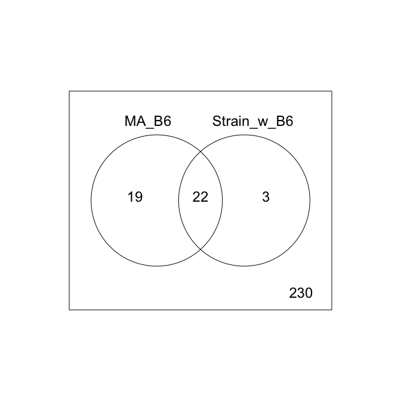

```r
results2 <- results[, 1:2]
vennDiagram(results2)
```

QQ-plot of limma t-statistics

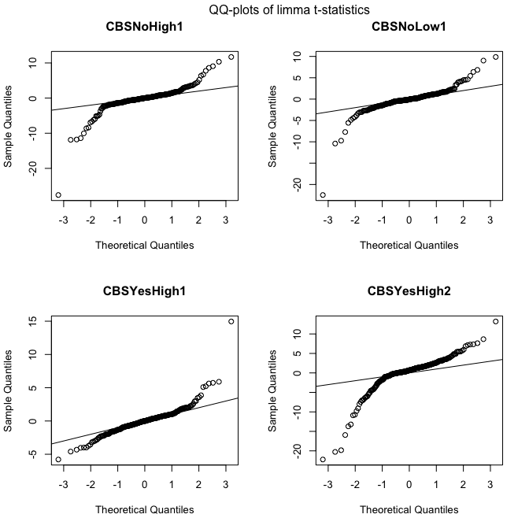

```r
par(mfrow=c(2,2))
for(i in 1:4)
  {
    qqt(DECu$t[,i],df=DECu$df.residual+DECu$df.prior,
        main=colnames(desCu)[i])
    abline(0,1)
  }
par(mfrow=c(1,1))
mtext("QQ-plots of limma t-statistics", line=3)
```

A volcano plot with more detail is shown later in the vignette, but a quick version is a native `limma` option.

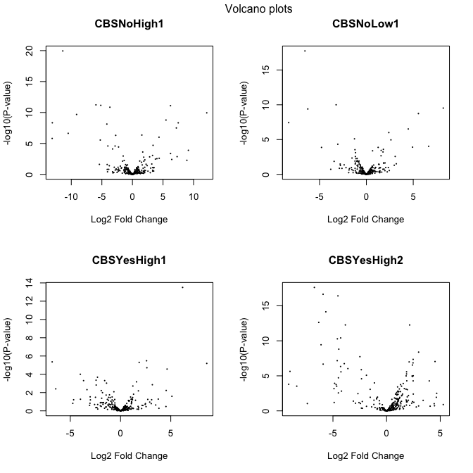

```r
par(mfrow=c(2,2))
for(i in 1:4)
volcanoplot(DECu, coef=i, main=colnames(desCu)[i])
par(mfrow=c(1,1))
mtext("Volcano plots", line=3)
```

## 0.7 Database Matching

Now that compounds that vary significantly for a specified contrast are identified, the function `dbMatch` can provide a first approximation of the compound identities.

** This is absolutely not a definitive identity**, which would require additional data.

Rather, `dbMatch` provides a list of matches based on compounds with a similar mass. If multiple putative annotations are found within the specified mass tolerance, 10 ppm by default, all are listed.

Warning: because multiple putative identifications are allowed, the output peak list may expand to larger than the input. When an input peak has more than one putative match, that row is duplicated, but then distinct annotations are appended for each match. Such duplicated rows can occur for real biochemical reasons (e.g., leucine and isoleucine), or technical artifacts (e.g., misshapen peaks), and/or in cases where the database contains distinct annotations that overlap the mass window. `dbMatch` cannot distinguish why a peak has more than one match, although the annotations may help to determine the reason.

- A closer match is not validation of a particular identity.
- Annotated objects should be maintained separately from the input object to best manage the peaks that are duplicated by annotation.

The use of chromatographic information (retention time) can greatly aid compound annotation. `dbMatch` includes arguments to allow retention time matching to a database that includes chromatographic information.

`dbMatch` requires that the user provide an appropriate database.  
In this example, `HMDB_Shortlist` contains compounds used as calibration standards in the CBS experiment. However, a larger list, such as all metabolites found in a yeast cell, can be used. If retention time matching is desired, the database must have the correct information matching the chromatographic system used, which would generally be laboratory-specific.

Warning! Do not publish annotations produced by `dbMatch`, nor are they even suitable for public presentation. In our experience with complex samples, more than half of the annotations are incorrect. Intended uses for `dbMatch` include:

- prioritizing the peaks to validate with standards or CID-MS in further experiments.
- filtering contaminant peaks [by their lack of annotation as organic compounds]
- filtering isotopes, alternative adducts, or multimers
- investigating mass/retention time clusters or class enrichment
- aligning new data to historical data.

```r
# Read in a list of knowns. hmdb_Shortlist contains a list
# of compounds used as calibration standards in the CBS experiment.
data(hmdb_Shortlist)
hmdb <- hmdb_Shortlist
```

Run `dbMatch`. The `mzmed` column in the `CBS.xcms_diffreport` is column 6. The `db_annotations` argument passes annotation information to the output object.

```r
x.ID_db <- dbMatch(x=CBS.xcms_diffreport, peaknames="name", mzmedcol="mzmed",
  db=hmdb, dbcol="Adduc_MW_.Da.", ppmCut=10, db_annotations=c("ID",
  "Formula", "HMDB_ID", "Adduct"))
```

```
#> [1] "No retention time detected.  Mass match only"
```

```r
# Both the peaklist and database have an "ID" column,
# so the merge failed with an error message.

# Change the name of the database column and re-run
names(hmdb)[1] <- "Metabolite"

x.ID_db <- dbMatch(x=CBS.xcms_diffreport, peaknames="name", mzmedcol="mzmed", db=hmdb,
  dbcol="Adduc_MW_.Da.", ppmCut=10,
  db_annotations=c("Metabolite", "Formula", "HMDB_ID", "Adduct"))
```

```
#> [1] "No retention time detected.  Mass match only"
```

`dbMatch` can be used on other input types, like a `limma` topTable object so that only significant hits are annotated. Read in a `topTable`, such as the significant metabolites from the CBS data ranked by F-test in the dataset `ttF.CBS`, merge with the mass info, keeping the `topTable` order, and annotate.

```r
ttF_anno <- merge(data.table(ttF.CBS), CBS.xcms_diffreport, by.x="ID", by.y="name",
                  all.x=TRUE, all.y=FALSE, sort=FALSE)

x.ID_db <- dbMatch(x=ttF_anno, peaknames="ID", mzmedcol="mzmed", db=hmdb,
  dbcol=4, ppmCut=10,
  db_annotations=c("Metabolite", "Formula", "HMDB_ID", "Adduct"))
```

```
#> [1] "No retention time detected.  Mass match only"
```

```r
# A fast check: pull only the database hits
# Now with a proper adjusted p-value
knitr::kable(x.ID_db[!is.na(exact_mz), c(1, 9, 14, 78, 81)],
             caption="CBS peaks matching standards")
```

CBS peaks matching standards

| ID | adj.P.Val | mzmed | exact_mz | Formula |
| --- | --- | --- | --- | --- |
| M116T279 | 0.0081598 | 116.0708 | 116.0706 | C5H9NO2 |
| M118T468 | 0.0000000 | 118.0863 | 118.0863 | C5H11NO2 |
| M120T220 | 0.0000003 | 120.0657 | 120.0655 | C4H9NO3 |
| M132T949 | 0.0000000 | 132.1021 | 132.1019 | C6H13NO2 |
| M147T264 | 0.0000000 | 147.1137 | 147.1128 | C6H14N2O2 |
| M150T549 | 0.0000000 | 150.0589 | 150.0583 | C5H11NO2S |
| M156T552 | 0.0001063 | 156.0725 | 156.0731 | (13)CH3S(13CH2)2(13)CH(15)NH2(13)CO2H |
| M166T1042 | 0.0000000 | 166.0865 | 166.0863 | C9H11NO2 |
| M170T976 | 0.0000202 | 170.0815 | 170.0812 | C8H11NO3 |
| M175T306 | 0.0000023 | 175.1202 | 175.1190 | C6H14N4O2 |
| M182T910 | 0.0000000 | 182.0820 | 182.0812 | C9H11NO3 |
| M205T1285 | 0.0002016 | 205.0974 | 205.0972 | C11H12N2O2 |
| M269T446 | 0.0000000 | 269.0639 | 269.0624 | C8H16N2O4S2 |
| M298T1133 | 0.0000000 | 298.0990 | 298.0968 | C11H15N5O3S |
| M308T503 | 0.0000000 | 308.0929 | 308.0911 | C10H17N3O6S |
| M385T1001 | 0.0000709 | 385.1303 | 385.1288 | C14H20N6O5S |
| M400T665 | 0.0000001 | 400.1492 | 400.1523 | C15H23N6O5S |

## 0.8 Data Visualizations

`limms` objects can be sliced to a shortlist of statistically significant compounds to use for data visualizations. There are many possible methods, but as for transcriptomics analyses, dot plots, volcano plots and heatmaps are useful.

Looking at the changes for the levels of one compound, stratified by covariates, is a good way to detect patterns.

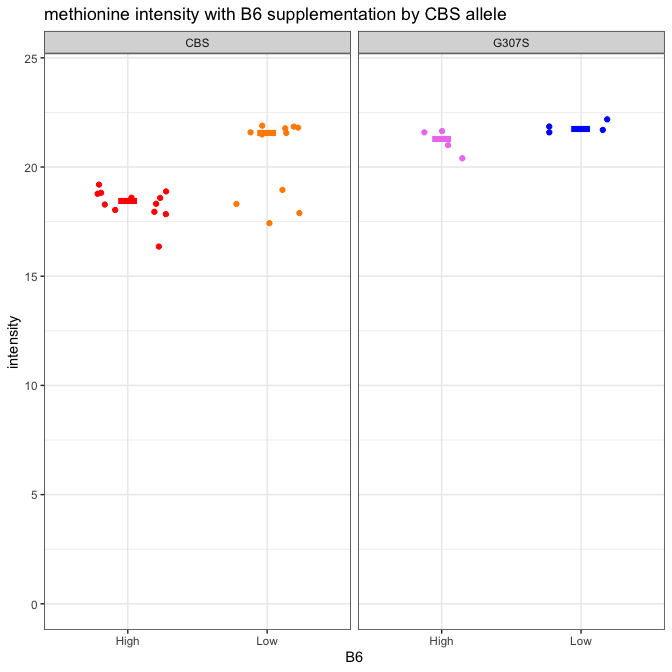

```r
# pull methionine
methionine <- melt(tT.F[name %in% "M269T446"], measure.vars=patterns("norm"),
  variable.name="sample", value.name="intensity")[, c(1,109:111)]

# append the B6 supplementation information
methionine[, B6 := desMetB6$B6]
methionine[, allele := desMetB6$Strain]

# Add identifying colors
methionine[, colorCBS_B6 := c("red", "darkorange", "violet", "blue")[as.factor(paste(
  desMetB6$Strain, desMetB6$B6, sep="_"))]]

ggplot(methionine, aes(x=B6, y=intensity, color=colorCBS_B6)) +
  geom_jitter(width=0.3) +
  stat_summary(fun="median", size=18, geom="point", shape="-") +
  scale_color_identity() +
  facet_wrap(~allele) +
  ylim(0, 24) +
  theme_bw() +
  ggtitle("methionine intensity with B6 supplementation by CBS allele")
```

A nicer volcano plot using `ggplot`

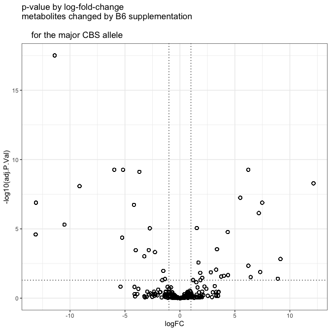

```r
# pull the topTable for contrast 1, B6 supplementation of the major allele only:
tt1.4volcano <- melt(tt1, measure.vars=patterns("norm"), variable.name="sample",
  value.name="intensity")[, c(1, 102, 106)]


ggplot(tt1.4volcano, aes(x=logFC, y=-log10(adj.P.Val))) +
    geom_point(shape=1, size=2) +
  theme_bw() +
    geom_hline(yintercept=1.30103, linetype="dotted") +
    geom_vline(xintercept=1, linetype="dotted") +
    geom_vline(xintercept=-1, linetype="dotted") +
  ggtitle("p-value by log-fold-change\nmetabolites changed by B6 supplementation\n
    for the major CBS allele")
```

A heatmap of the most significant hits in the vitamin B6 contrast.

```r
# apply p-value and log-fold-change cutoffs

tt1.pCut <- limmaTest(x=all.fq, peaknames="name", intensities=102:133, des=desCu,
  cont=contMatrix, coef=1, p.value=0.01, lfc=2)
```

```
#> [1] "For data.table input, assign columns using the 'peaknames' and 'intensities' arguments"
#>        MA_B6 Strain_w_B6 Strain_by_B6 CBS_Met
#> Down      18          11            8      36
#> NotSig   233         249          257     193
#> Up        23          14            9      45
```

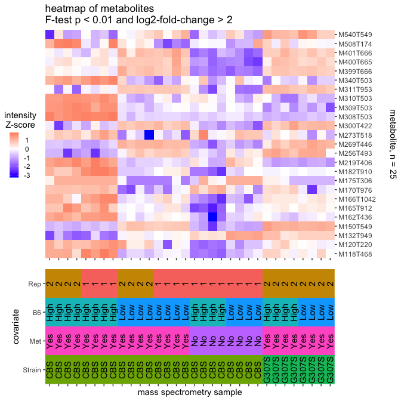

```r
# down to 26 metabolites, a reasonable number for a heatmap

tt1.scaled <- data.table(reshape2::melt(tt1.pCut[, .(name, .SD), .SDcols=patterns("norm")],
  id.vars=1, variable.name="sample", value.name="intensity"))
tt1.scaled[, scaled := scale(.SD), by=name, .SDcols="intensity"]

# make the heatmap
hm.tt1 <- ggplot(tt1.scaled, aes(x=fct_inorder(sample), y=name, fill=scaled)) +
  geom_raster() +
  scale_fill_gradient2(low="blue", mid="white", high="red") +
  scale_y_discrete(position="right", limits=rev(levels(tt1.scaled$name))) +
  coord_cartesian(expand=FALSE) +
  theme(axis.text.x=element_blank(), axis.title.x=element_blank(), legend.position="left",
        legend.text.align=0.5, legend.margin=margin(0,0,0,0, unit="pt"),
        legend.key.size=unit(0.4, "cm"), legend.title.align=0.5) +
  guides(fill="colorbar") +
  labs(fill="intensity\nZ-score") +
    ylab("metabolite, n = 25\n") +
  ggtitle("heatmap of metabolites\nF-test p < 0.01 and log2-fold-change > 2")
# map classes onto the samples
desMetB6.melt <- melt(data.table(desMetB6), id.vars="Run", variable.name="covariate",
  value.name="class")

# make a covariates table
hm.classes <- ggplot(desMetB6.melt, aes(x=fct_inorder(Run), y=covariate, fill=class)) +
  geom_raster() +
  geom_text(aes(label=class), angle=90) +
  coord_cartesian(expand=FALSE) +
  theme(axis.text.x=element_blank(), legend.position="none", legend.text.align=0.5, legend.margin=margin(0,0,0,0, unit="pt"), legend.key.size=unit(0.4, "cm"),
        legend.title.align=0.5) +
  xlab("mass spectrometry sample")

# put the heatmap and table together
plot_grid(hm.tt1, hm.classes, nrow=2, rel_heights=c(0.66, 0.34), axis="lr", align="v")
```

## 0.9 Version Info

```r
sessionInfo(package="limms")[5]
```

```
#> $tzcode_type
#> [1] "internal"
```